# Natural Language Processing Course

Tanaka Manhede

February 2026

# Introduction

This document serves as a central repository for assignments, and cleaning genies. The assignment section contains subsections highlighting a different coding assignment.

# Assignments

This segment contains all assignments

## Assignment 1

For the first assignment, I am going to produce a string called “Mary had a little lamb” in one code block. Then I am going to split the string to one word per row. Next, I am going to add a variable called Nletters that counts the letters in each word. The other part of the assignment is to style the css to personal needs.  
So, step one is to produce the string “Mary had a Little Lamb”

```r
my_string <- "Mary had a little lamb"

print(my_string)
```

```
## [1] "Mary had a little lamb"
```

Now, we are going to take the string “Mary had a little lamb” and put it into a data frame that counts the number of letters/characters in each word. The challenge is being able to create a table that I can simply change the string and it will automatically update:

```r
# This splits the sentence by word, given that there is a space inserted
# between each word
words = str_split(my_string, " ")

# This is a data frame that serves to list out the words in the sentence and
# the number of letters or characters in each word. It has been formated this
# way so that a different sentence can be inserted and formatted as a data
# frame
df.lambchops <- data.frame(x = words, y = NA)

# I am renaming the column with more appropriate names. (haha lamb chops)
colnames(df.lambchops)[1] <- "Words"
colnames(df.lambchops)[2] <- "N_letters"

# For the N_letters column, here we are counting the number of characters or
# letters in each word that has its own row
df.lambchops$N_letters <- nchar(df.lambchops$Words)

print(df.lambchops)
```

```
##    Words N_letters
## 1   Mary         4
## 2    had         3
## 3      a         1
## 4 little         6
## 5   lamb         4
```

## Assignment 2

Well it looks like we have another assignment, this one took a little more elbow grease than the last time…

First step is loading in the file needed to be cleaned.

1. Read ‘sticks_messy.txt’ into R

```r
# Here, I am loading in the messy_txt to clean
messy_txt <- readLines("/Users/tanakamanhede/Documents/GitHub/project_nlpcourse26/Manhede_RData/Week2_nlp/data/sticks_messy.txt")
```

I combined the next steps into a function called springcleaning

2. Create a cleaning function with at least three chained procedures
3. Clean the text file using your homemade cleaning function
4. Split the text file into a one-word-per row format

```r
springcleaning <- function() {

    # This line removes punctuations and replaces it with no space to push the
    # word token together or removes an extra space
    gonestring.punct <- gsub("[[:punct:]]", "", messy_txt)
    # Removes numbers and replaces it with no space to push the word token
    # togetheror removes an extra space
    gonestring.num <- gsub("[[:digit:]]", "", gonestring.punct)
    # Removes extra abnormal spaces and replaces it with one space to separate
    # word tokens
    gonestring.sp <- gsub("[[:space:]]", " ", gonestring.num)
    # Splits the words by space
    splitstring = strsplit(gonestring.num, " ")
    # Unlisting the texts in the file
    splitstring.unlist <- unlist(splitstring)
    # This makes a data frame with a word per row
    df_lambchops <- data.frame(x = splitstring.unlist)
    # A new data fram is made and excludes cells that are empty
    df_lamb <- df_lambchops %>%
        filter(x != "")

    # Renaming the column for organizational purposes to 'Words' instead of 'x'
    colnames(df_lamb)[1] <- "Words"
    # Returning a new data frame!
    return(df_lamb)

}

springcleaning()
```

| x |
| --- |
| Every |
| year |
| hlj |
| Thanksgiving |
| n |
| ight |
| O |
| we |
| flocked |
| OIHJOIJ |
| out |
| behind |
| Dad |
| as |
| he |
| KPOANL |
| dragged |
| the |
| Santa |
| suit |
| to |
| the |
| road |
| and |
| draped |
| it |
| over |
| a |
| kind |
| of |

[output cut: 170 more lines]

5. Tell me how many words are in the story

```r
# I am counting the number of rows since it represents the number of words in
# the text
nrow(springcleaning())
```

```
## [1] 401
```

6. Compute type token ratio

```r
ttr <- function() {
    # Counting how many words are in the function to find the total word token
    tokens <- nrow(springcleaning())
    # Counting the number of unique word tokens in the data frame
    type <- length(unique(springcleaning()$Words))
    # Need to make the values of each variable numeric so that I can perform
    # the operation;It will not work on characters
    as.numeric(tokens)
    as.numeric(type)
    # Creating a formula to take the number of unique word tokens and divide it
    # by the total number of tokens in the text
    TTR <- type/tokens

    return(TTR)
}

ttr()
```

```
## [1] 0.5710723
```

All done!

Keep an eye out for assignment 3!

## Assignment 3

```r
messy_txt <- readLines("/Users/tanakamanhede/Documents/GitHub/project_nlpcourse26/Manhede_RData/Week2_nlp/data/sticks_messy.txt")
```

```r
springcleaning2.0 <- function() {

    # Loading in stop words from SMART and MIT
    load("/Users/tanakamanhede/Documents/GitHub/project_nlpcourse26/Manhede_RData/Week3_nlp/data/SMART_stops.rda")

    load("/Users/tanakamanhede/Documents/GitHub/project_nlpcourse26/Manhede_RData/Week3_nlp/data/MIT_stops.rda")

    load("/Users/tanakamanhede/Documents/GitHub/project_nlpcourse26/Manhede_RData/Week3_nlp/data/replacements_25.rda")

    messy_txt <- gsub("[[:digit:]]", "", messy_txt)

    # Making all the words in the text lowercase
    gtext.low <- tolower(messy_txt)

    # Removing words from the SMART list
    gtext.smart <- gsub(paste0("\\b(", paste(SMART_stops$word, collapse = "|"), ")\\b"),
        "", gtext.low)

    # Replacing contractions with their government names; I unlocked a new R
    # code setNames
    gtext.cont <- str_replace_all(gtext.smart, setNames(replacements_25$replacement,
        replacements_25$word))

    # Removing stop words using MIT (Most Important Text)
    gtext.MIT <- gsub(paste0("\\b(", paste(MIT_stops$word, collapse = "|"), ")\\b"),
        "", gtext.cont)

    # Removing erroneous punctuation from the text
    gtext <- gsub("[[:punct:]]", "", gtext.MIT)

    # Removing random spaces from the text
    gtext2 <- gsub("[[:space:]]", " ", gtext)

    # Splits the words by space
    splitstring2.0 = strsplit(gtext2, " ")

    # Unlisting the texts in the file
    splitstring.unlist2.0 <- unlist(splitstring2.0)

    # This makes a data frame with a word per row (I like lamb chops
    # (literally), so I kept it)
    df_lambchops2.0 <- data.frame(x = splitstring.unlist2.0)

    # A new data fram is made and excludes cells that are empty
    df_lamb2.0 <- df_lambchops2.0 %>%
        filter(x != "")

    # Renaming the column for organizational purposes to 'Words' instead of 'x'
    colnames(df_lamb2.0)[1] <- "Words"

    # Returning a new data frame!
    return(df_lamb2.0)
}


# *Cracks knuckles* Moment of truth
springcleaning2.0()
```

| x |
| --- |
| year |
| hlj |
| thanksgiving |
| n |
| ight |
| o |
| flocked |
| oihjoij |
| dad |
| kpoanl |
| dragged |
| santa |
| suit |
| road |
| draped |
| kind |
| crucifix |
| built |
| metal |
| pole |
| yard |
| super |
| bowl |
| week |
| pole |
| dressed |
| jersey |
| rods |
| helmet |
| rod |

[output cut: 167 more lines]

The function is now tested:

```r
# For my next feat, I have pulled texts from The Onion to test the cleaning
# genie2.0!
messy_txt <- c("Facing intense backlash and scrutiny from critics who say the reference book publisher had failed to take all words into consideration, Merriam-Webster was accused of bias Monday after officially selecting ‘dictionary’ as its 2025 word of the year. “Merriam-Webster clearly has a pro-dictionary bias that’s preventing it from considering all words equally,” lexicographer Alison Nielsen wrote in a widely shared social media post that lambasted the Merriam-Webster editorial team, claiming its members had allowed a “personal affinity for looking up words” to cloud their judgment. “I was willing to overlook it last year when their word of the year was ‘definition,’ but I can’t allow myself to turn a blind eye to this. The Merriam-Webster editorial board is stuck in its own media bubble. They need to look around and read a thesaurus once in a while.” At press time, reports confirmed Merriam-Webster appeared to have doubled down by changing the 2025 word of the year to “dictionaries.”",
    "“I love having this killer coat in the winter, especially when me and my buddies are cruising around and blasting tunes in my old Mustang, which doesn’t have any heat,” said Lockhart, stretching his lean frame over a pool table to sink a bank shot as he spoke to reporters about how he spends much of his time fixing up the muscle car, which has a faded King Cobra decal on the hood. “Bundle Up Our Bad Boys understands that when a guy like me looks good, he feels good. I’ve become more successful in all areas of my life, whether it’s picking up broads, fighting some jock who dissed me, or street racing at night around a deadly bend on the edge of town.”",
    "Stifling their groans as an instructor distributed the wailing infants, students at the Culinary Institute of America were reportedly given a live baby Friday to learn how to care for a bag of flour. “Flour is the most delicate of the pantry staples, and looking after this child for the week will prepare you to deal with the complexities of milled grain,” said Inès Allard, who teaches introduction to baking and pastry at the school, explaining that the students would have to keep the baby from leaking just as they would need to do with an actual sack of processed wheat. “I know it’s not a real bag of flour, but it’s important to take this seriously. And trust me, this is easy mode—babies can be left out in the open, but if you do that with flour, you get ants. If you can’t handle a live infant, then you sure as hell aren’t ready for 10 pounds of ultra-fine pizza flour crafted from the highest-quality varieties of soft wheat.” At press time, reports indicated that many students had already decided it would be too much work to have a flour bag of their own.")
```

All texts are courtesy of The Onion and their talented writers. Please view here: [The Onion: Dictionary](https://theonion.com/merriam-webster-accused-of-bias-after-dictionary-named-word-of-the-year/), [The Onion: Leather Jacket](https://theonion.com/community-leather-coat-drive-helps-bad-boys-in-need/), [The Onion: Chef Baby](https://theonion.com/culinary-students-given-live-baby-to-learn-how-to-care-for-bag-of-flour/)

```r
springcleaning2.0()
```

| x |
| --- |
| facing |
| intense |
| backlash |
| scrutiny |
| critics |
| reference |
| book |
| publisher |
| failed |
| words |
| consideration |
| merriamwebster |
| accused |
| bias |
| monday |
| officially |
| selecting |
| dictionary |
| word |
| year |
| merriamwebster |
| prodictionary |
| bias |
| s |
| preventing |
| words |
| equally |
| lexicographer |
| alison |
| nielsen |

[output cut: 170 more lines]

## Assignment 4

1. Use Quanteda and base R for this assignment 2)Submit as HTML (link or file) using your own css styled output
2. Style it like a real report describing what you are doing at each step and why
3. Read in unabomber from my github repo
4. Output its structure

The unabomber text is analyzed. Here, the text is named “messy_txt”

```r
# Unabomber text is read in
messy_txt <- paste(readLines("https://raw.githubusercontent.com/Reilly-ConceptsCognitionLab/reillylab_publicdata/main/unabomber_manifesto.txt"))
```

A new cleaning genie for quanteda is made to output a text rather than a data frame

```r
raw_txt <- readLines("https://raw.githubusercontent.com/Reilly-ConceptsCognitionLab/reillylab_publicdata/main/unabomber_manifesto.txt")

unabomb_quanteda <- function() {

    # Loading in r data stopwords for cleaning
    load("/Users/tanakamanhede/Documents/GitHub/project_nlpcourse26/Manhede_RData/Week3_nlp/data/SMART_stops.rda")
    load("/Users/tanakamanhede/Documents/GitHub/project_nlpcourse26/Manhede_RData/Week3_nlp/data/MIT_stops.rda")
    load("/Users/tanakamanhede/Documents/GitHub/project_nlpcourse26/Manhede_RData/Week3_nlp/data/replacements_25.rda")

    # Standardizes font punctuation not recognized by code to be used in the
    # function
    utf8_normalize <- function(x) {
        stringi::stri_enc_toutf8(as.character(x), is_unknown_8bit = FALSE, validate = TRUE)
    }

    # Replacing apostrophes and quotes
    unabomb_quanteda_unr.apos <- stringr::str_replace_all(utf8_normalize(x = raw_txt),
        "[“”\"″˝‟„]", " ")

    # Applies lowercase to all the text
    unabomb_quanteda_lower <- tolower(unabomb_quanteda_unr.apos)

    # Removing digits and spaces
    unabomb_quanteda_digits <- gsub("[[:digit:]]", " ", unabomb_quanteda_lower)
    unabomb_quanteda_space <- gsub("[[:space:]]", " ", unabomb_quanteda_digits)

    # Replacing contractions with the appropriate expansion
    unabomb_quanteda_contractions <- stringr::str_replace_all(unabomb_quanteda_space,
        setNames(replacements_25$replacement, nm = replacements_25$word))

    # Converting the stopwords columns from each data frame into appropriate
    # form to be able to remove stop words
    sw <- unique(c(MIT_stops$word, SMART_stops$word))
    sw <- sw[nzchar(sw)]
    sw <- gsub("([][{}()+*^$|\\\\?.])", "\\\\\\1", sw)

    unabomb_quanteda_nostops <- gsub(paste0("\\b(", paste(sw, collapse = "|"), ")\\b"),
        "", unabomb_quanteda_contractions, perl = TRUE)

    # Removes punctuation except periods by replacing punctuation with spaces
    unabomb_quanteda_punct <- gsub("(?!\\.)[[:punct:]]", " ", unabomb_quanteda_nostops,
        perl = TRUE)
    # Replaces any and all whitespace into a single space
    unabomb_quanteda_final <- gsub("[[:space:]]+", " ", unabomb_quanteda_punct)

    # Cleans up any remaining spaces as a result of removal of punctuation
    unabomb_quanteda_final <- gsub("^ | $", "", unabomb_quanteda_final)

    return(unabomb_quanteda_final)
}
```

The cleaned text is transformed into a corpus and a summary is generated.

```r
# Loading in the quanteda library
library(quanteda)

# Assigning the unabomb_quanteda function into an object
clean_txt <- unabomb_quanteda()

# The data is converted to a corpus for further analysis
my_simple_corpus <- corpus(clean_txt)

# The corpus is tokenized, removing numbers, punctuation, and separating space
clean_tokenized <- tokens(my_simple_corpus, remove_numbers = TRUE, remove_punct = TRUE,
    remove_separators = TRUE)

# Showing data for the corpus
summary(my_simple_corpus)
```

| Text | Types | Tokens | Sentences |
| --- | --- | --- | --- |
| text1 | 3 | 3 | 1 |
| text2 | 0 | 0 | 0 |
| text3 | 1 | 1 | 1 |
| text4 | 0 | 0 | 0 |
| text5 | 5 | 5 | 1 |
| text6 | 7 | 7 | 1 |
| text7 | 5 | 5 | 1 |
| text8 | 8 | 8 | 1 |
| text9 | 5 | 5 | 1 |
| text10 | 7 | 7 | 1 |
| text11 | 6 | 6 | 1 |
| text12 | 7 | 8 | 1 |
| text13 | 6 | 6 | 1 |
| text14 | 6 | 6 | 1 |
| text15 | 4 | 4 | 1 |
| text16 | 0 | 0 | 0 |
| text17 | 6 | 7 | 1 |
| text18 | 7 | 7 | 1 |
| text19 | 5 | 5 | 1 |
| text20 | 6 | 6 | 1 |
| text21 | 7 | 7 | 1 |
| text22 | 5 | 5 | 1 |
| text23 | 4 | 4 | 1 |
| text24 | 6 | 6 | 1 |
| text25 | 0 | 0 | 0 |
| text26 | 5 | 6 | 1 |
| text27 | 6 | 6 | 1 |
| text28 | 3 | 4 | 1 |
| text29 | 1 | 1 | 1 |
| text30 | 0 | 0 | 0 |

[output cut: 70 more lines]

A table of lexical characteristics is generated

```r
# Creating a tokenized version of the corpus tokens_unabomb, removing
# punctuation and stopwords
tokens_unabomb <- tokens(clean_txt, remove_punct = TRUE) %>%
    tokens_remove(stopwords("SMART"))

# Creating a document-feature matrix, stemming is applied
md_dfm_unabomb <- dfm(tokens_unabomb, dfm_stem = TRUE)
topfeatures(md_dfm_unabomb, 15)
```

```
##    society     system     people      power      human technology     social
##        237        221        218        167        140        127         98
## industrial     modern    freedom    process       make   problems    leftist
##         97         94         90         73         70         68         67
##        man
##         63
```

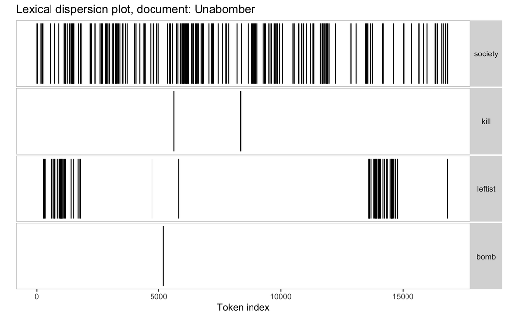

```r
# Loading in the quanteda textplots library
library("quanteda.textplots")

# Text is collapsed for the textplot_xray to work
clean_txt_2 <- paste(clean_txt, collapse = " ")
names(clean_txt_2) <- "Unabomber"

# Determining where the following words appear in the text in time
textplot_xray(kwic(tokens(clean_txt_2), pattern = "society"), kwic(tokens(clean_txt_2),
    pattern = "kill"), kwic(tokens(clean_txt_2), pattern = "leftist"), kwic(tokens(clean_txt_2),
    pattern = "bomb"), kwic(tokens(clean_txt_2), pattern = "cleanse"), scale = "absolute")
```

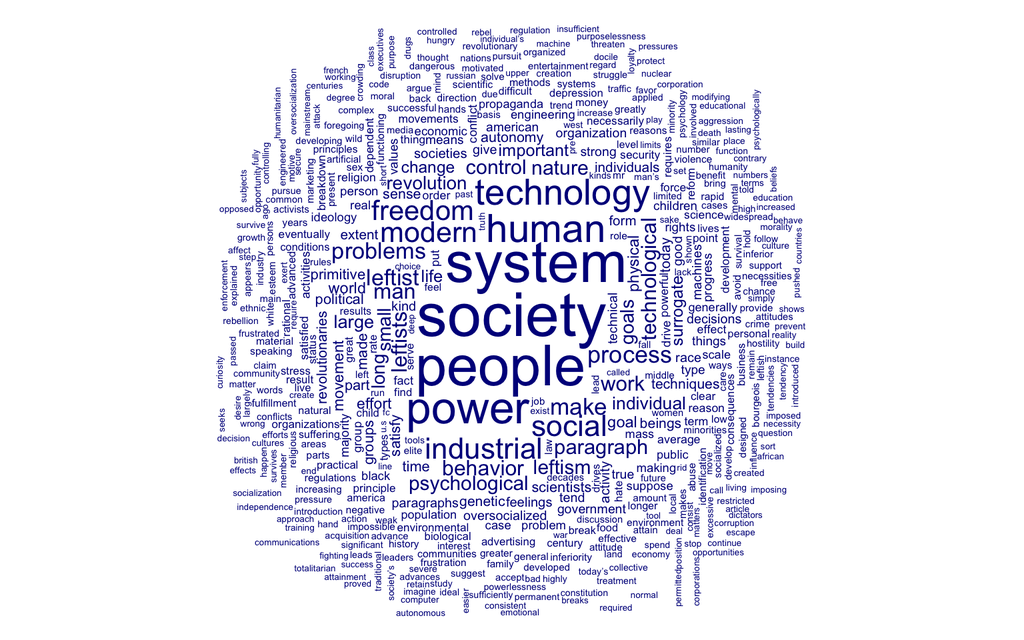

```r
# This word cloud prints a visual representation of the most common words
# represented by size
quanteda.textplots::textplot_wordcloud(md_dfm_unabomb, random_order = FALSE, rotation = 0.25)
```

```r
# Printing out the top twenty most common words in the text
topfeatures(md_dfm_unabomb, 20)
```

```
##       society        system        people         power         human
##           237           221           218           167           140
##    technology        social    industrial        modern       freedom
##           127            98            97            94            90
##       process          make      problems       leftist           man
##            73            70            68            67            63
##      leftists      behavior technological          work     paragraph
##            62            61            60            59            58
```